# HW_regression_clear

Dmitrii Belousov

2025-01-04

# Оценка физической активности

Согласно описанию, мы можем предположить, что следующие переменные могут быть косвенно связаны с уровнем физической активности:

- **DRQSDT8** - Weight gain/Muscle building diet.
- **DRQSDT10** - High protein diet.
- **PAQ605** - Vigorous work activity.
- **PAQ610** - Number of days vigorous work.
- **PAD615** - Minutes vigorous-intensity work.
- **PAQ635** - Walk or bicycle.
- **PAQ640** - Number of days walk or bicycle.
- **PAD645** - Minutes walk/bicycle for transportation.
- **PAQ650** - Vigorous recreational activities.
- **PAQ655** - Days vigorous recreational activities.
- **PAD660** - Minutes vigorous recreational activities.

Характеристики когорты по параметрам физической активности:

| **Characteristic** | **N = 916** |
| --- | --- |
| Weight.gain.diet |  |
| 1 | 5 (0.5%) |
| 2 | 911 (99%) |
| High.protein.diet |  |
| 1 | 4 (0.4%) |
| 2 | 912 (100%) |
| Vigorous.work |  |
| 1 | 176 (19%) |
| 2 | 740 (81%) |
| Vigorous.work.days |  |
| 0 | 740 (81%) |
| 1 | 19 (2.1%) |
| 2 | 22 (2.4%) |
| 3 | 24 (2.6%) |
| 4 | 17 (1.9%) |
| 5 | 60 (6.6%) |
| 6 | 13 (1.4%) |
| 7 | 21 (2.3%) |
| Vigorous.work.min |  |
| Mean (SD) | 32 (89) |
| Median (25%-75%) | 0 (0-0) |
| Minimum-Maximum | 0-660 |
| Walk.bicycle |  |
| 1 | 211 (23%) |
| 2 | 705 (77%) |
| Walk.bicycle.days |  |
| 0 | 705 (77%) |
| 1 | 12 (1.3%) |
| 2 | 21 (2.3%) |
| 3 | 29 (3.2%) |
| 4 | 17 (1.9%) |
| 5 | 59 (6.4%) |
| 6 | 8 (0.9%) |
| 7 | 65 (7.1%) |
| Walk.bicycle.min |  |
| Mean (SD) | 13 (39) |
| Median (25%-75%) | 0 (0-0) |
| Minimum-Maximum | 0-480 |
| Vigorous.recr |  |
| 1 | 191 (21%) |
| 2 | 725 (79%) |
| Vigorous.recr.days |  |
| 0 | 725 (79%) |
| 1 | 22 (2.4%) |
| 2 | 41 (4.5%) |
| 3 | 46 (5.0%) |
| 4 | 29 (3.2%) |
| 5 | 29 (3.2%) |
| 6 | 14 (1.5%) |
| 7 | 10 (1.1%) |
| Vigorous.recr.min |  |
| Mean (SD) | 16 (39) |
| Median (25%-75%) | 0 (0-0) |
| Minimum-Maximum | 0-360 |

Могу предположить, что показатель гликированного гемоглобина может быть ассоццирован с тремя основными факторами: 1. Количество потребляемых углеводов, то есть качество и тип пищевого поведения;  
2. Скорость метаболизма глюкозы в печени и других органах, скорость конвертации в другие молекулы (жирные кислоты, аминокислоты, гликоген);  
3. **Потребление глюкозы мышцами**.

Эти три фактора так или иначе должны объединять в себе все остальные, приведенные на графе. Характеристики когорты по новым параметрам физической активности:

| **Characteristic** | **N = 913** |
| --- | --- |
| Physical.act.min |  |
| Mean (SD) | 133 (176) |
| Median (25%-75%) | 60 (0-180) |
| Minimum-Maximum | 0-960 |
| Physical.act.ord |  |
| 0 | 231 (25%) |
| 1 | 306 (34%) |
| 2 | 224 (25%) |
| 3 | 100 (11%) |
| 4 | 42 (4.6%) |
| 5 | 10 (1.1%) |

Профиль физической активности у субъектов когорты:

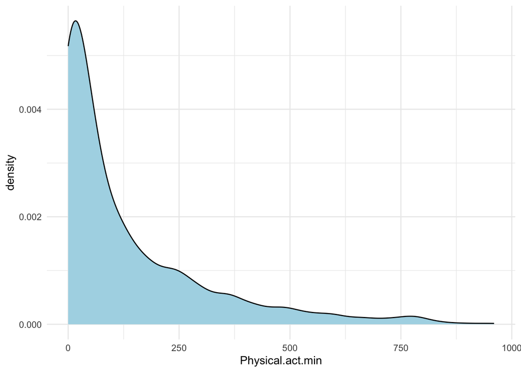

Зависимость уровня гликированного гемоглобина от уровня физической активности:

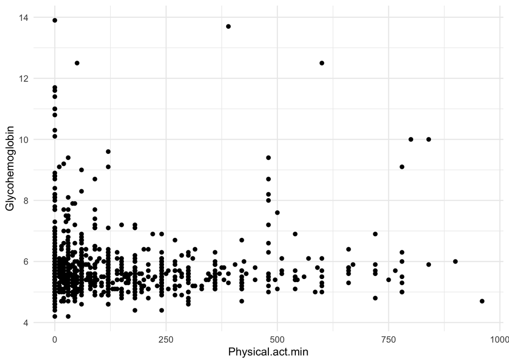

Можно заметить обратную нелинейную зависимость (не каузальную) уровня гликированного гемоглобина от физической активности, пациенты с высоким (более 300 минут) имеют больший разброс уровняли гликированного гемоглобина. Исходя из этого, можно разделить пациентов на следующией группы: `Zero`: 0 минут физической активности, `Average`: нижние 75% пациентов по физической активности, у которых она выше нуля; `High`: верхние 25% пациентов по физической активности, у которых она выше нуля.

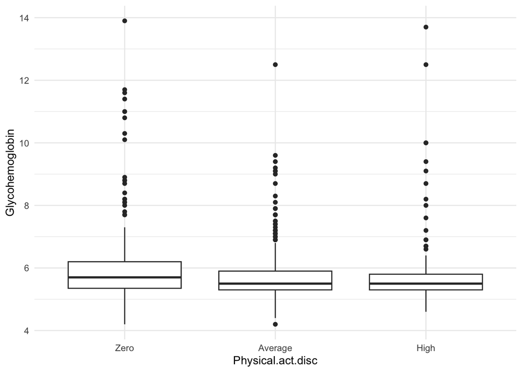

Профиль уровня гликированного гемоглобина по когорте:

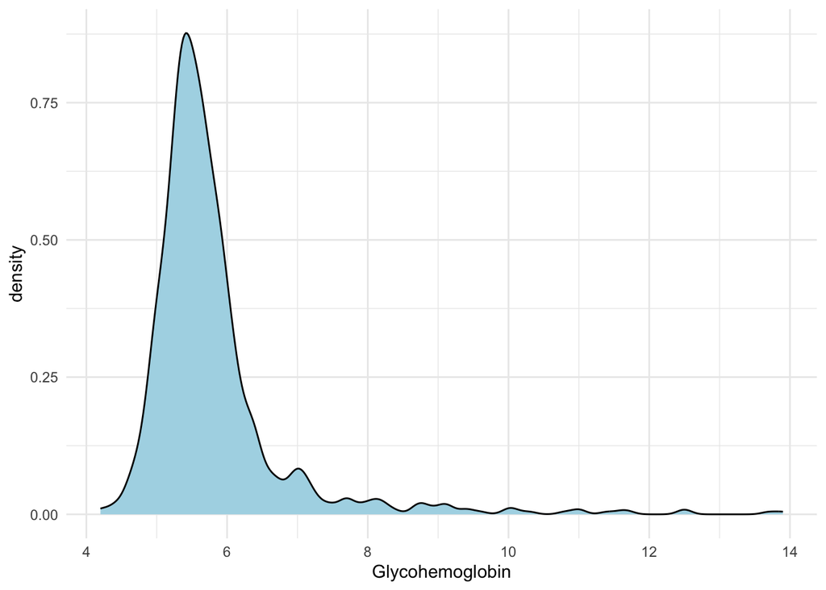

```r
data %>%
  rename(Glycohemoglobin = LBXGH) %>%
  ggplot() +
  geom_density(aes(x=Glycohemoglobin), fill="lightblue", color="black") +
  theme_minimal()
```

Чтобы линеаризовать зависимость и сдвинуть распределение к более нормальному проведем логарифмическую трансформацию:

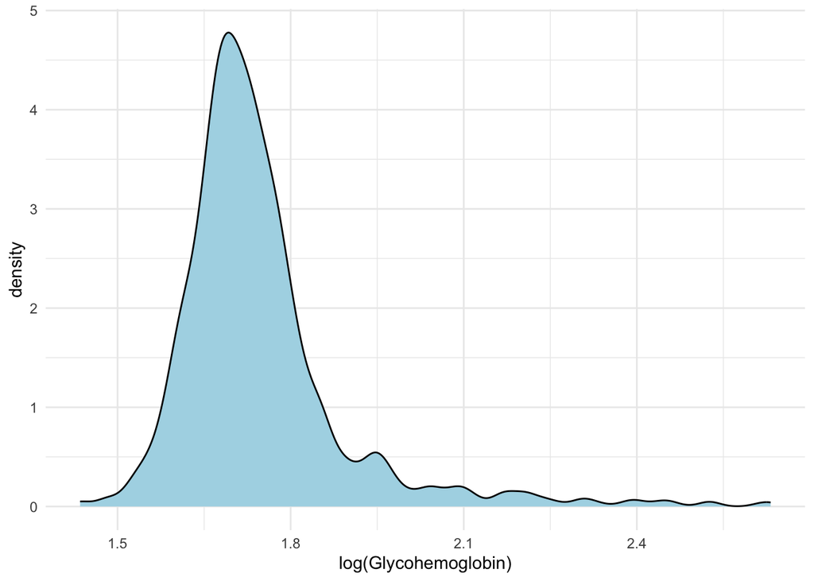

```r
data %>%
  rename(Glycohemoglobin = LBXGH) %>%
  ggplot() +
  geom_density(aes(x=log(Glycohemoglobin)), fill="lightblue", color="black") +
  theme_minimal()
```

Параметры из графа:

*Race* - конфаундер  
*Education* - конфаундер  
*Family income* - конфаундер  
*Smoking* - прокси-конфаундер  
*Age* - конфаундер  
*Comorbidities* - конфаундер  
*Sex* - конфаундер  
*Blood pressure* - коллайдер  
*Diabetic medication* - коллайдер  
*Marital status* - instrumental variable

На первом этапе я собираюсь включить в модель все конфаундеры, а затем, если необходимо, убрать те, которые не объясняют никакой дополнительной вариации отклика, при помощи goodness-of-fit тестов. Также необходимо учесть наличие инструментальной переменной, на первом этапе, я буду контролировать то, что она не скоррелирована с зависмой перменной (физической активностью) и нескоррелирована с остатками модели.

Помимо включенных в граф факторов, я также считаю необходимым внести в модель фактор, отражающий потребление углеводов.

Из коморбидностей я не буду включать в граф помимо повышенного давления коронарную болезнь сердца, инфаркт и инсульт, так как это тоже коллайдеры.

# Регрессионный анализ

На первом этапе построим избыточную модель:

```
##
## Call:
## lm(formula = formula_full, data = data_prepared %>% filter(Energy <
##     10000))
##
## Residuals:
##      Min       1Q   Median       3Q      Max
## -0.40840 -0.06793 -0.01795  0.03439  0.83289
##
## Coefficients:
##                                 Estimate Std. Error t value Pr(>|t|)
## (Intercept)                    1.261e+00  8.634e-02  14.603  < 2e-16 ***
## Physical.act.discAverage      -2.098e-02  1.105e-02  -1.899 0.057907 .
## Physical.act.discHigh          5.919e-03  1.450e-02   0.408 0.683280
## SexMale                        1.487e-02  1.039e-02   1.430 0.152940
## Age.Years                      2.503e-03  3.281e-04   7.629 6.17e-14 ***
## RaceBlack                     -1.497e-02  1.926e-02  -0.777 0.437147
## RaceHispanic                  -4.239e-02  1.950e-02  -2.174 0.029966 *
## RaceOther                     -9.167e-02  3.191e-02  -2.873 0.004170 **
## RaceWhite                     -7.420e-02  1.718e-02  -4.318 1.75e-05 ***
## Education.L                   -3.276e-02  1.558e-02  -2.102 0.035855 *
## Education.Q                    1.394e-02  1.300e-02   1.072 0.284017
## Education.C                   -4.516e-03  1.128e-02  -0.400 0.688978
## Education^4                   -1.122e-02  1.005e-02  -1.116 0.264584
## log(BMI)                       1.454e-01  2.185e-02   6.656 4.97e-11 ***
## log(Alcohol.Consumption + 1)  -1.224e-02  3.170e-03  -3.861 0.000121 ***
## Low.SaltYes                    3.251e-02  2.988e-02   1.088 0.276872
## Energy                         2.030e-05  6.130e-06   3.312 0.000965 ***
## Family.Income.L               -4.244e-04  2.125e-02  -0.020 0.984071
## Family.Income.Q               -3.742e-03  1.880e-02  -0.199 0.842271
## Family.Income.C                6.684e-03  1.856e-02   0.360 0.718776
## Family.Income^4               -2.955e-02  1.806e-02  -1.636 0.102171
## Family.Income^5                3.284e-02  1.823e-02   1.802 0.071886 .
## Family.Income^6                1.746e-02  1.782e-02   0.980 0.327462
## Family.Income^7                2.691e-02  1.732e-02   1.554 0.120620
## Family.Income^8               -4.412e-03  1.684e-02  -0.262 0.793439
## Family.Income^9               -1.164e-02  1.634e-02  -0.712 0.476567
## Family.Income^10              -1.341e-02  1.583e-02  -0.847 0.397307
## Family.Income^11               2.311e-02  1.442e-02   1.602 0.109481
## log(Total.Sugars + 1)         -2.742e-02  8.171e-03  -3.355 0.000826 ***
## Smoking.StatusFormer.Smoker    5.125e-03  1.062e-02   0.483 0.629509
## Smoking.StatusFrequent.Smoker  2.316e-02  1.428e-02   1.622 0.105188
## Smoking.StatusRare.Smoker      1.640e-02  2.533e-02   0.647 0.517609
## AsthmaYes                      6.812e-03  1.561e-02   0.436 0.662661
## Thyroid.DiseaseYes             2.099e-02  1.521e-02   1.380 0.167949
## COPDYes                       -2.413e-02  2.304e-02  -1.047 0.295310
## Malignancy.StatusYes           2.729e-02  1.494e-02   1.827 0.068042 .
## ---
## Signif. codes:  0 '***' 0.001 '**' 0.01 '*' 0.05 '.' 0.1 ' ' 1
##
## Residual standard error: 0.1317 on 876 degrees of freedom
## Multiple R-squared:  0.2231, Adjusted R-squared:  0.192
## F-statistic: 7.186 on 35 and 876 DF,  p-value: < 2.2e-16
```

После экспериментирования и визуальной диагностики модели, оказалось, что некоторые параметры лучше прологарифмировать. Более того, судя по всему, в наших данных есть проблема с гетероскедастичностью, что нарушает предположения линейной модели. Эту проблему не получилось решить трансформациями, поэтому пришлось прибегнуть к моделям другого типа (glm с Gamma распределением, gls с различными поправками дисперсии), но это так же не помогло побороть гетерескдеастичность.

## Диагностика избыточной модели

Модель действительно сильно подвержена гетерскедастичности, что видно по расширяющемуся “облаку” остатков:

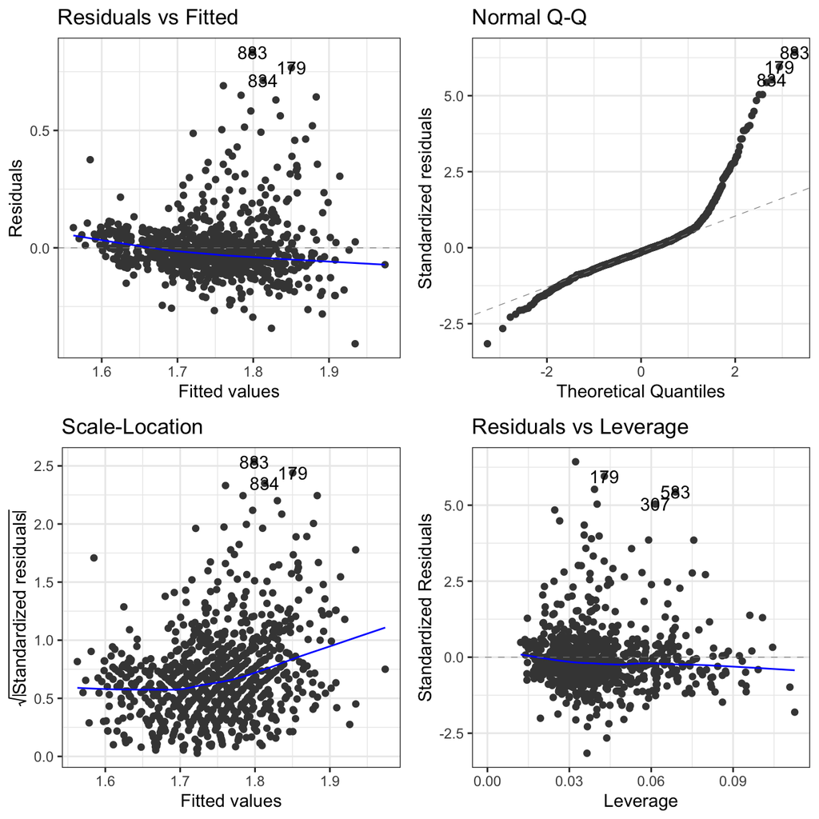

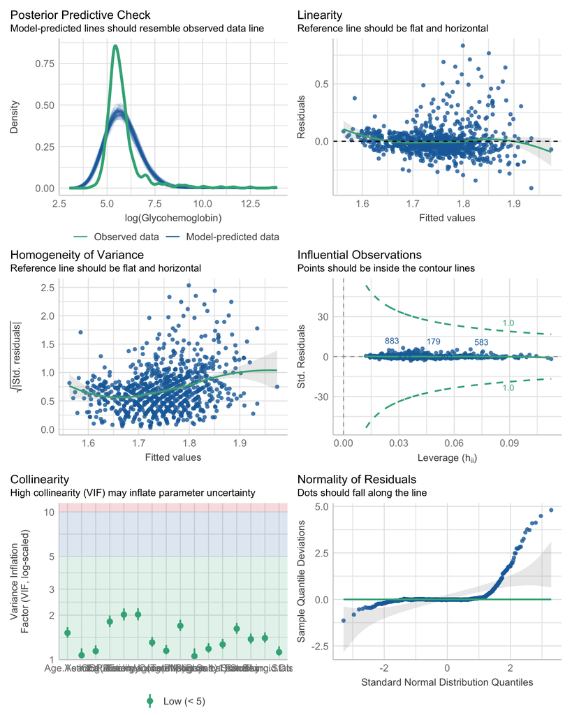

При этом сильных выбросов в модели нет:

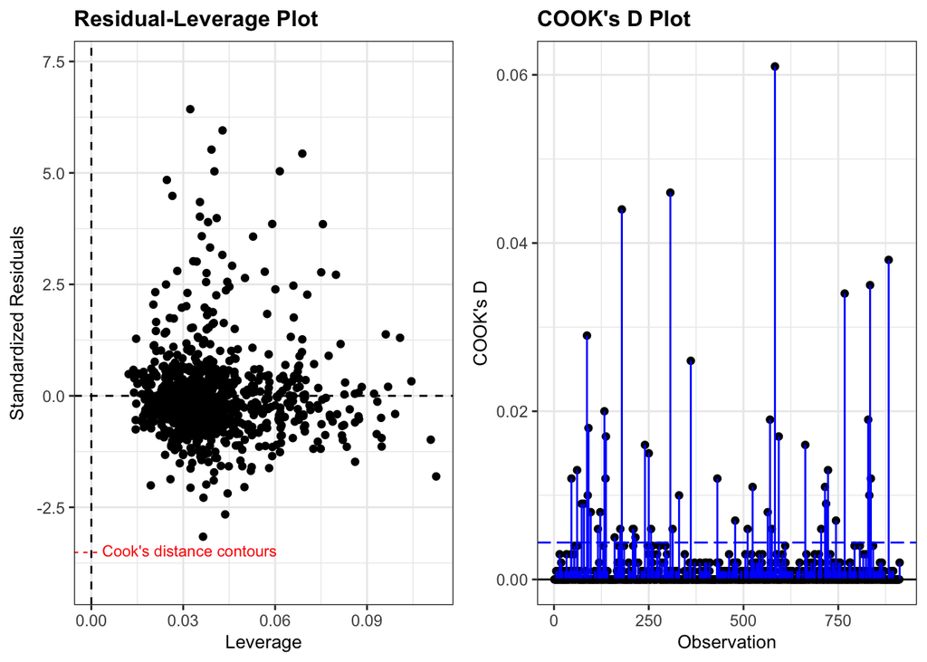

По ассоциациям с предикторами мы так же не наблюдаем сильных выбросов:

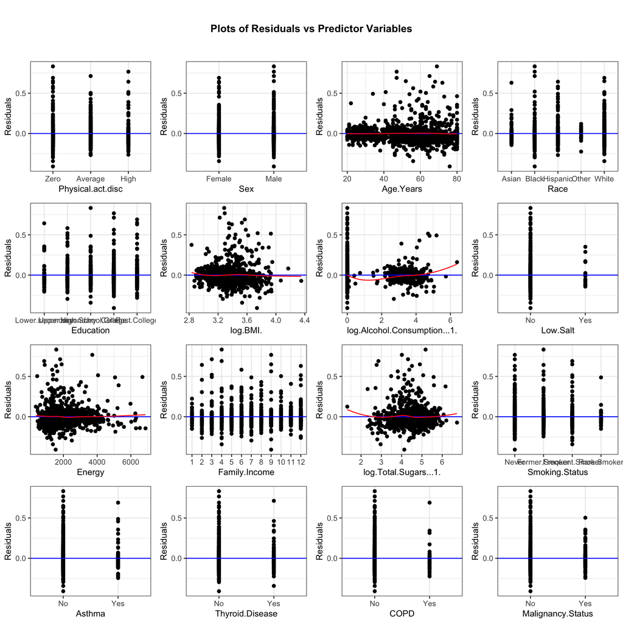

Инструментальная переменная (`Marital.Status`) не связана с остатками (ANOVA):

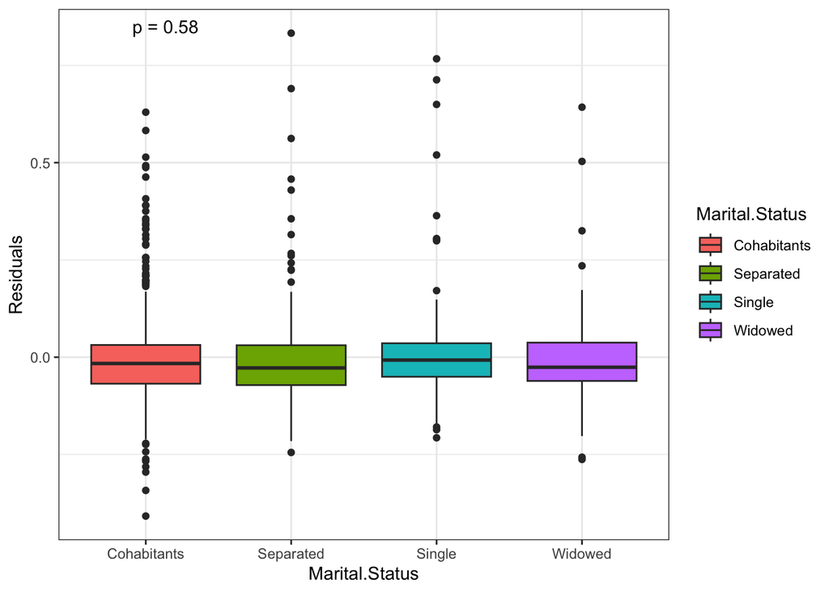

## Подгонка модели

При помощи других подходов с различными вариациями мне не получилось побороть гетероскедастичность, поэтому далее я буду использовать линейную модель, для которой затем буду корректировать стандартные ошибки.

ANOVA analysis results

|  | df | statistic | p.value |
| --- | --- | --- | --- |
| Physical.act.disc | 2 | 3.0512 | 0.0478 |
| Sex | 1 | 1.8505 | 0.1741 |
| Age.Years | 1 | 68.4323 | 0.0000 |
| Race | 4 | 11.5927 | 0.0000 |
| Education | 4 | 1.3539 | 0.2482 |
| log(BMI) | 1 | 38.6980 | 0.0000 |
| log(Alcohol.Consumption + 1) | 1 | 16.2118 | 0.0001 |
| Low.Salt | 1 | 0.9043 | 0.3419 |
| Energy | 1 | 7.1872 | 0.0075 |
| Family.Income | 11 | 1.2671 | 0.2386 |
| log(Total.Sugars + 1) | 1 | 6.9939 | 0.0083 |
| Smoking.Status | 3 | 0.7844 | 0.5027 |
| Asthma | 1 | 0.1573 | 0.6917 |
| Thyroid.Disease | 1 | 1.3961 | 0.2377 |
| COPD | 1 | 0.7677 | 0.3812 |
| Malignancy.Status | 1 | 3.3792 | 0.0664 |
| Residuals | 876 | NA | NA |

Можно обратить внимание, что размер эффекта некоторых факторов в избыточной модели не отличается значимо от нуля. Подтвердим наблюдение при помощи анализа goodness-of-fit вложенных моделей:

| term | statistic | p.value |
| --- | --- | --- |
| Physical.act.disc | 3.35179 | 0.03547 |
| Sex | 2.04623 | 0.15294 |
| Age.Years | 58.19857 | 0.00000 |
| Race | 9.57290 | 0.00000 |
| Education | 1.48536 | 0.20458 |
| log(BMI) | 44.29905 | 0.00000 |
| log(Alcohol.Consumption + 1) | 14.91017 | 0.00012 |
| Low.Salt | 1.18385 | 0.27687 |
| Energy | 10.96728 | 0.00097 |
| Family.Income | 1.19479 | 0.28607 |
| log(Total.Sugars + 1) | 11.25924 | 0.00083 |
| Smoking.Status | 0.92070 | 0.43024 |
| Asthma | 0.19044 | 0.66266 |
| Thyroid.Disease | 1.90431 | 0.16795 |
| COPD | 1.09656 | 0.29531 |
| Malignancy.Status | 3.33787 | 0.06804 |

Исключив незначимые факторы, получим финальную модель:

| term | estimate | std.error | statistic | p.value |
| --- | --- | --- | --- | --- |
| (Intercept) | 1.27145 | 0.08387 | 15.15964 | 0.00000 |
| Physical.act.discAverage | -0.02399 | 0.01088 | -2.20475 | 0.02772 |
| Physical.act.discHigh | 0.00119 | 0.01429 | 0.08345 | 0.93351 |
| Age.Years | 0.00259 | 0.00029 | 8.86305 | 0.00000 |
| RaceBlack | -0.01159 | 0.01861 | -0.62299 | 0.53345 |
| RaceHispanic | -0.02986 | 0.01847 | -1.61668 | 0.10630 |
| RaceOther | -0.08328 | 0.03142 | -2.65095 | 0.00817 |
| RaceWhite | -0.07048 | 0.01665 | -4.23418 | 0.00003 |
| log(BMI) | 0.14275 | 0.02150 | 6.64058 | 0.00000 |
| log(Alcohol.Consumption + 1) | -0.01167 | 0.00309 | -3.77740 | 0.00017 |
| Energy | 0.00002 | 0.00001 | 3.93778 | 0.00009 |
| log(Total.Sugars + 1) | -0.02828 | 0.00807 | -3.50520 | 0.00048 |

Проверим гипотезу модификации эффекта физической активности на гликированный гемоглобин в зависимости от биологического пола:

| term | df | sumsq | meansq | statistic | p.value |
| --- | --- | --- | --- | --- | --- |
| Physical.act.disc | 2 | 0.39320 | 0.19660 | 11.24574 | 0.00002 |
| Age.Years | 1 | 1.34550 | 1.34550 | 76.96374 | 0.00000 |
| Race | 4 | 0.75779 | 0.18945 | 10.83651 | 0.00000 |
| log(BMI) | 1 | 0.93171 | 0.93171 | 53.29481 | 0.00000 |
| log(Alcohol.Consumption + 1) | 1 | 0.10023 | 0.10023 | 5.73312 | 0.01685 |
| Energy | 1 | 0.09236 | 0.09236 | 5.28280 | 0.02177 |
| log(Total.Sugars + 1) | 1 | 0.21460 | 0.21460 | 12.27531 | 0.00048 |
| Sex | 1 | 0.02500 | 0.02500 | 1.42978 | 0.23212 |
| Physical.act.disc:Sex | 2 | 0.01324 | 0.00662 | 0.37879 | 0.68480 |
| Residuals | 897 | 15.68158 | 0.01748 | NA | NA |

В данном случае мы не можем отвергнуть нулевую гипотезу и в дальнейшее включение в модель факторов пола и взаимодействия пола и физической активности не имеет смысла.

| Factor | Estimate | SE | t.value | p.value | lwr.CI | upr.CI | Change | lwr.CI.change | upr.CI.change |
| --- | --- | --- | --- | --- | --- | --- | --- | --- | --- |
| (Intercept) | 3.56600 | 0.08457 | 15.03420 | 0.00000 | 3.02064 | 4.20983 | 2.56600 | 2.02064 | 3.20983 |
| Physical.act.discAverage | 0.97629 | 0.01231 | -1.94910 | 0.05159 | 0.95299 | 1.00017 | -0.02371 | -0.04701 | 0.00017 |
| Physical.act.discHigh | 1.00119 | 0.01637 | 0.07286 | 0.94194 | 0.96955 | 1.03387 | 0.00119 | -0.03045 | 0.03387 |
| Age.Years | 1.00259 | 0.00026 | 10.02344 | 0.00000 | 1.00208 | 1.00310 | 0.00259 | 0.00208 | 0.00310 |
| RaceBlack | 0.98848 | 0.01833 | -0.63246 | 0.52724 | 0.95355 | 1.02468 | -0.01152 | -0.04645 | 0.02468 |
| RaceHispanic | 0.97058 | 0.01683 | -1.77376 | 0.07644 | 0.93904 | 1.00318 | -0.02942 | -0.06096 | 0.00318 |
| RaceOther | 0.92009 | 0.02216 | -3.75835 | 0.00018 | 0.88093 | 0.96099 | -0.07991 | -0.11907 | -0.03901 |
| RaceWhite | 0.93194 | 0.01420 | -4.96462 | 0.00000 | 0.90633 | 0.95828 | -0.06806 | -0.09367 | -0.04172 |
| log(BMI) | 1.15345 | 0.02274 | 6.27806 | 0.00000 | 1.10310 | 1.20609 | 0.15345 | 0.10310 | 0.20609 |
| log(Alcohol.Consumption + 1) | 0.98840 | 0.00291 | -4.00914 | 0.00007 | 0.98277 | 0.99406 | -0.01160 | -0.01723 | -0.00594 |
| Energy | 1.00002 | 0.00001 | 3.24832 | 0.00120 | 1.00001 | 1.00004 | 0.00002 | 0.00001 | 0.00004 |
| log(Total.Sugars + 1) | 0.97212 | 0.00990 | -2.85778 | 0.00436 | 0.95342 | 0.99118 | -0.02788 | -0.04658 | -0.00882 |

Интерпретация:

Физическая активность на среднем уровне снижает уровень гликированного гемоглобина при прочих равных на 2.37%. Поскольку доверительный интервал оценок коэффициентов (Estimate) включает 1 и р-значение > 0.05 для Average, то можно говорить о том, что средняя физическая активность при прочих равных не значимо влияет на уровень гликированного гемоглобина.

Оценка влияния физической активности без учета остальных ковариат:

| Factor | Estimate | SE | t.value | p.value | lwr.CI | upr.CI | Change | lwr.CI.change | upr.CI.change |
| --- | --- | --- | --- | --- | --- | --- | --- | --- | --- |
| (Intercept) | 5.93838 | 0.01205 | 147.78428 | 0.00000 | 5.79954 | 6.08055 | 4.93838 | 4.79954 | 5.08055 |
| Physical.act.discAverage | 0.95171 | 0.01315 | -3.76421 | 0.00018 | 0.92746 | 0.97659 | -0.04829 | -0.07254 | -0.02341 |
| Physical.act.discHigh | 0.96263 | 0.01729 | -2.20337 | 0.02782 | 0.93052 | 0.99585 | -0.03737 | -0.06948 | -0.00415 |

Изменение уровня гликированного гемоглобина отличается в ожидаемую сторону (мы ожидали снижение), тем не менее, вероятно, другие ковариаты, связанные с физической активностью, объясняют часть эффекта, что делает размер эффектов физической активности статистически незначимо отличающимся от нуля в полной модели.

В этом исследовании (https://pmc.ncbi.nlm.nih.gov/articles/PMC4310078/) в популяции здоровых субъектов процент гликированного гемоглобина варьируется в диапазоне +-9.14%. Исходя из этого значения, я бы сделал вывод о клинической незначимости влияния параметра физической активности на процент гликированного гемоглобина в данной популяции.